# Lab: Exploring Data using IBM Cloud Gallery

### Load Data

```r
setwd("~/Documents/Coursera/CERT_IBM DSPC/IBM DSPC/01_WhatIsDataScience/0 - Data/")
fire_raw <- read.csv("forest+fires/forestfires.csv")

library(tidyverse) #ofc
library(viridis) #better ggplot colors
```

# Take a Look at the Data

```r
head(fire)
```

|  | X | Y | month | day | FFMC | DMC | DC | ISI | temp | RH | wind | rain | area |
| --- | --- | --- | --- | --- | --- | --- | --- | --- | --- | --- | --- | --- | --- |
| 1 | 7 | 5 | mar | fri | 86.2 | 26.2 | 94.3 | 5.1 | 8.2 | 51 | 6.7 | 0.0 | 0 |
| 2 | 7 | 4 | oct | tue | 90.6 | 35.4 | 669.1 | 6.7 | 18.0 | 33 | 0.9 | 0.0 | 0 |
| 3 | 7 | 4 | oct | sat | 90.6 | 43.7 | 686.9 | 6.7 | 14.6 | 33 | 1.3 | 0.0 | 0 |
| 4 | 8 | 6 | mar | fri | 91.7 | 33.3 | 77.5 | 9.0 | 8.3 | 97 | 4.0 | 0.2 | 0 |
| 5 | 8 | 6 | mar | sun | 89.3 | 51.3 | 102.2 | 9.6 | 11.4 | 99 | 1.8 | 0.0 | 0 |
| 6 | 8 | 6 | aug | sun | 92.3 | 85.3 | 488.0 | 14.7 | 22.2 | 29 | 5.4 | 0.0 | 0 |

# Data Dictionary

[source](https://archive.ics.uci.edu/dataset/162/forest+fires)

| Variable | Definition |
| --- | --- |
| X | x-axis spatial coordinate within the Montesinho park map: 1 to 9 |
| Y | y-axis spatial coordinate within the Montesinho park map: 2 to 9 |
| month | month of the year: “jan” to “dec” |
| day | day of the week: “mon” to “sun” |
| FFMC | FFMC index from the FWI system: 18.7 to 96.20 |
| DMC | DMC index from the FWI system: 1.1 to 291.3 |
| DC | DC index from the FWI system: 7.9 to 860.6 |
| ISI | ISI index from the FWI system: 0.0 to 56.10 |
| temp | temperature in Celsius degrees: 2.2 to 33.30 |
| RH | relative humidity in %: 15.0 to 100 |
| wind | wind speed in km/h: 0.40 to 9.40 |
| rain | outside rain in mm/m2 : 0.0 to 6.4 |
| area | the burned area of the forest (in ha): 0.00 to 1090.84[^1] |

[^1] : “this output variable is very skewed towards 0.0, thus it may make sense to model with the logarithm transform.”

# EDA

rather than going through all of the variables right now, let’s just look at the first variable **FFMC**

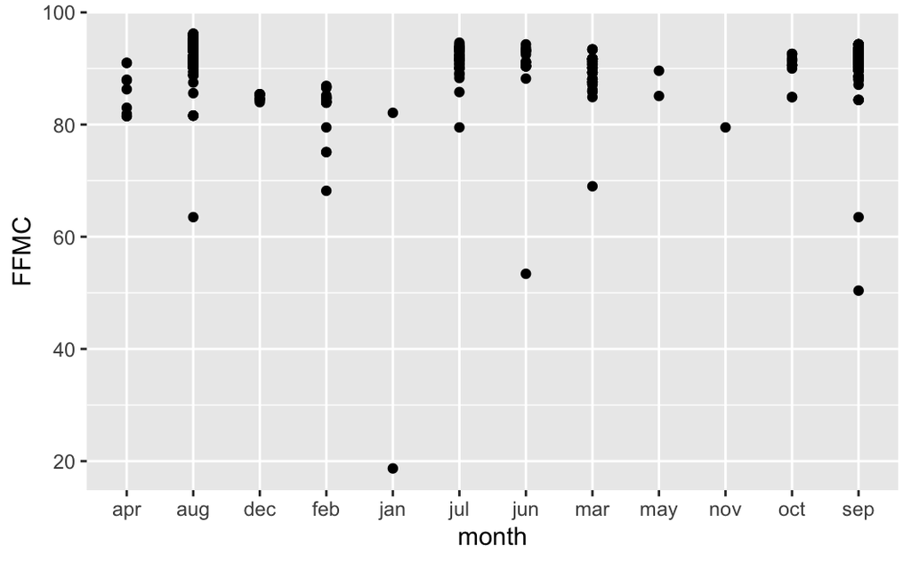

```r
fire_raw %>%
  ggplot(aes(month, FFMC)) +
  geom_point()
```

It seems the month value is text and we’d like to have the data be able to be ordered chronologically. Let’s clean this up a little:

- store in new table to maintain integrity of original dataset
- order the month data chronologically rather than alphabetically
- use a violin graph to better communicate the density of the fine fuel moisture content data points
- add some color to the graph

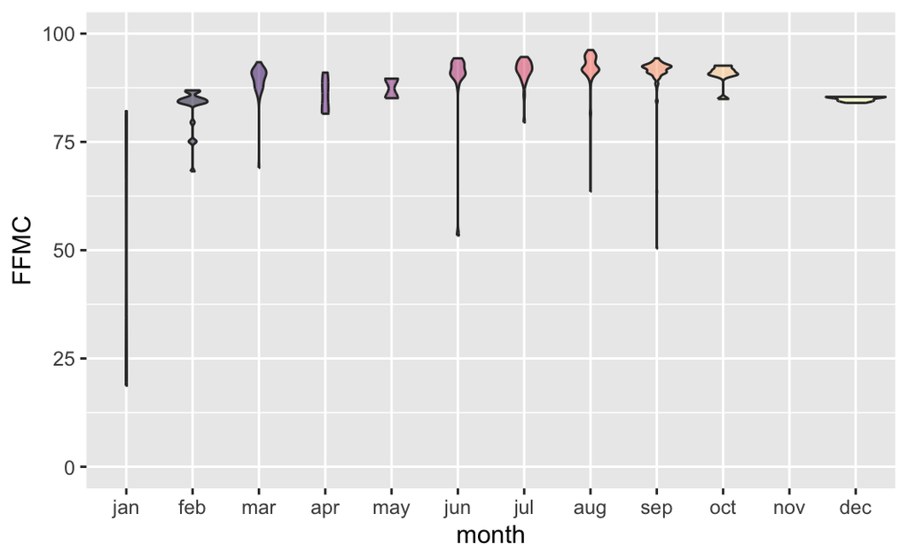

```r
# month order
monthChron <- c("jan",
                "feb",
                "mar",
                "apr",
                "may",
                "jun",
                "jul",
                "aug",
                "sep",
                "oct",
                "nov",
                "dec")

fire %>% # store changes in new table 'fire'
  mutate(month = fct_relevel(month, monthChron)) %>% # reorder months
  ggplot(aes(
    x = month,
    y = FFMC,
    fill = month)) +
  geom_violin(position='dodge', alpha=0.5) + # violin graph
  scale_fill_viridis(discrete=T, option="magma") + # magma colors
  ylim(0,100) + # change y scale to reflect entire FWI FFMC index range
  theme(legend.position = "none") # remove redundant legend showing month's colors
```

## Fine Fuel Moisture Code (FFMC)

The Fine Fuel Moisture Code is a measure of how easily a fire could ignite and how fast it could spread.

There are six components: 3 fuel moisture codes: 1. litter and other fine fuels 2. loosely compacted organic layers of moderate depth 3. deep, compact organic layers 3 are fire behavior indices: 4. rate of fire spread 5. fuel available for combustion 6. frontal fire intensity

| Rating | Danger |
| --- | --- |
| 0 - 80 | Low |
| 81 - 87 | Moderate |
| 88 - 90 | High |
| 91 - 92 | Very High |
| 93+ | Extreme |

## Conclusion

unsurprisingly, the fine fuel moisture code is higher in the summer seasons where the danger rating stays mostly in the high to very high range

contrary to the cool month of march, the danger level is just as high as june, july, and september. further analysis is needed to speculate why.